# Visualizing Data of Incarcerated Individuals in the United States

Amrith Gandham

2022-11-01

## Abstract

The United States has the largest incarcerated population in the world. It is the main form of punishment when individuals are convicted of a crime at the local, state, or federal level. Many assume that the judicial and legal system in the U.S. is a fair and trustworthy. However, that is not the case in which this project will explore the injustice and inequalities people face across the country.

## Introduction

This data provided by the Vera Institute will help us explore various trends of incarceration at the most basic levels from counties, regions, and states. This report will primarily analyze data based on individuals’ race and explore correlations and instances of inequalities that take place across the country. But before we can dive into the analysis, we need to think about how this data can impact the people around us and the individuals who’ve been incarcerated. The direct stakeholders of this report can be the people who are incarcerated and their families. An indirect stakeholder could be judges, prosecutors, lawyers, and the government since they all have a part in actually incarcerating a person. Some questions that we will answer and evaluate in this report are: *Which state has the highest rate of Black population incarcerated versus White population incarcerated?* *Which county has the highest average Black jail population vs their White Population?* *Which state has the highest average number of LatinX population incarcerated?*

## Data Summary

A notable way to explore and find inequalities through data analysis is to come up a similar set of questions and compare them against each other. My first question was *Which state has the highest average number of LatinX population incarcerated as of 2018?* The answer to that is California with an average number of **582.1358621** of LatinX individuals incarcerated. It’s important to note here that data from the Census shows that about 35% of California’s population is White with Hispanics/LatinX people making up about 40%. These are the 2 largest races in California yet, LatinX people are jailed at a disproportionate rate. The average number of White people jailed in California as of 2018 is **379.0977586**, a stark difference from the LatinX number. In addition, we can evaluate *Which state has the the highest average number of AAPI population incarcerated in 2018?*, which is **35.3282759** people, also in the state of California. This can tell us a lot about the processes and judicial systems present in California and for the need of oversight. Lastly there is the question of *Which state has the highest RATE of Black population incarcerated in 2018?* The answer to that is **0.3643438**%, in the state of Louisiana. This means that about 0.36% of the population in Louisiana are jailed Black individuals. In comparison to **0.2285987**% of the population in Louisiana which are incarcerated White individuals. We can notice there is an approximately 0.14% jump which may not seem like a lot but we are talking in the perspective of the state’s population.

## Growth of the U.S. Prison Population

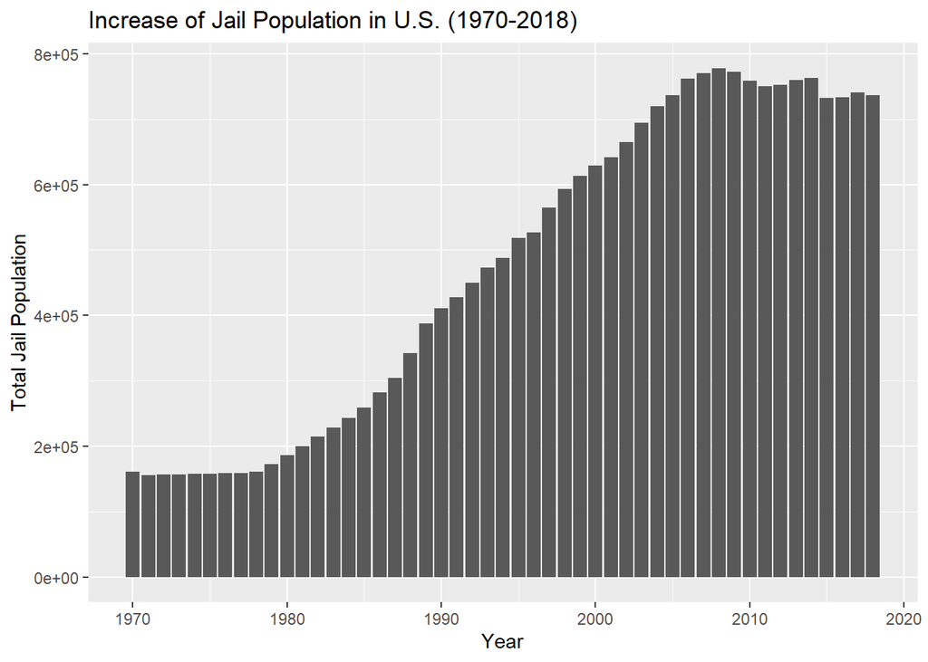

This chart displays the total jail population increase over time from the range of 1970 to 2018.

## Growth of Prison Population by State

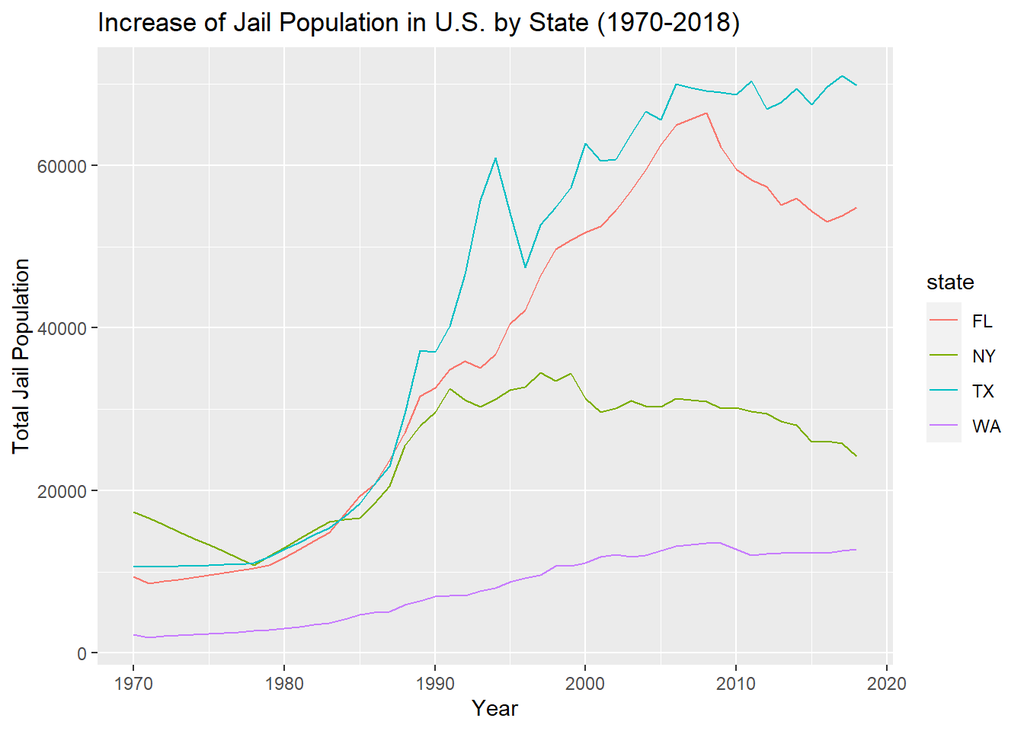

This chart displays the increase of total jail population over time for the states of Florida, New York, Texas, and Washington.

## In-County Comparison

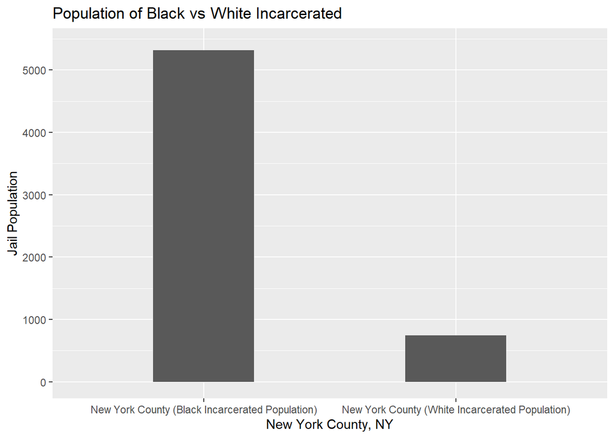

This chart displays the jail population of Black and White persons in New York County, NY.

- The question I brought up in order to generate this chart was *What is the county with the highest average Black jail population?* And in conjunction I also wanted to take a look at that same county’s White jail population. I found that the county with the highest average Black jail population was New York County located in New York state. Then I went ahead and calculated the White incarcerated population for New York County and put these pieces together to generate this chart. It displays a very significant difference in how many more Black individuals are jailed than White individuals were by a long shot. It spurs new questions of how are Black individuals being jailed at such a staggering rate than White individuals in New York County.

# Map Representation of the Ratio of Black to White Individuals Incarcerated

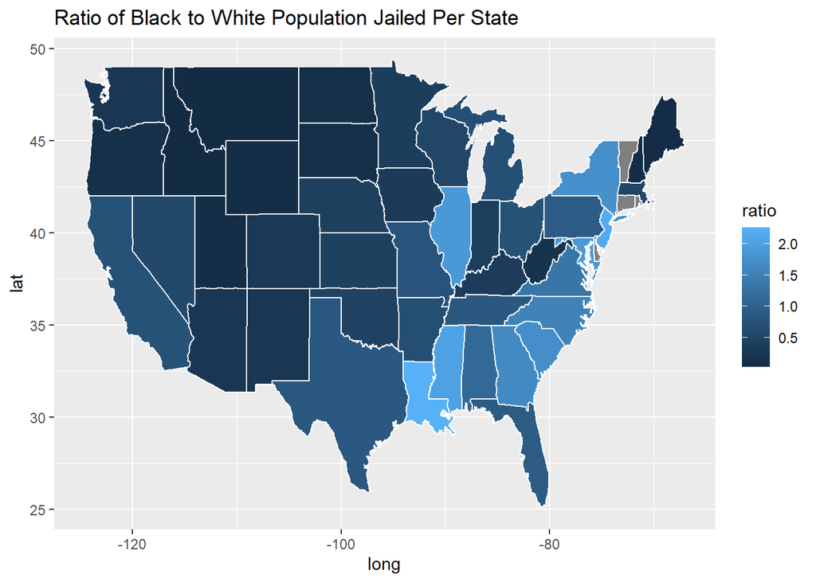

This map displays the ratio of Black to White individuals incarcerated for each state. States that are marked in grey did not have sufficient data to display.

- This map shows a geographical representation of the U.S. that is based on the ratio of Black to White individuals incarcerated in each state. I came up with the question of *Which states have a higher Black to White incarcerated rate?*, and thought this was the best way possible to represent that data. The ratio is calculated by getting the total population of Black individuals incarcerated divided by total White individuals incarcerated. As the ratio gets higher or, in this case the color gets lighter, it means the state has a higher number of Black individuals incarcerated versus White individuals. We can notice a pattern in the Southeastern and Northeastern states do indeed have higher ratios compared to other states across the country. Overall, states on the Western side of the country tend to have lower ratios of Black to White incarcerated persons.